# data_621_hw_4

## MODEL - MULTILINEAR REGRESSION (TARGET_AMT)

Let’s turn our focus to build two multilinear regression models using the same data. Interestingly, the variables do not seem to correlate with the target variable in this exercise. Nothing seems to indicate anything relevant to “target_amt”.

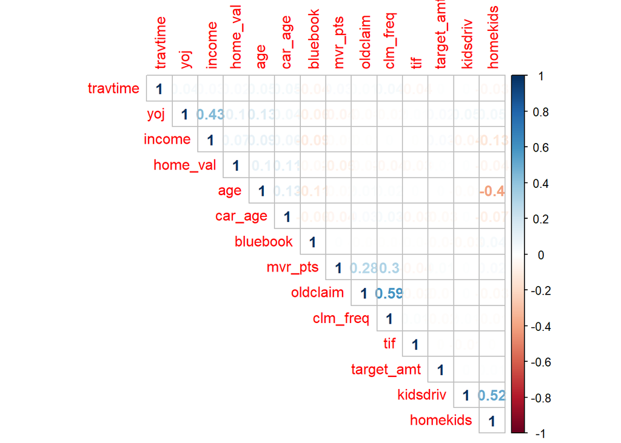

```r
# corrplot - quantitative variables
trainSet %>%
        dplyr::filter(target_flag == "Yes") %>%
        dplyr::select(fields %>% dplyr::filter(class != 'factor') %>% .$fields) %>%
        dplyr::select(-index) %>%
        cor %>%
        corrplot(method = "number", type = "upper", order = "hclust")
```

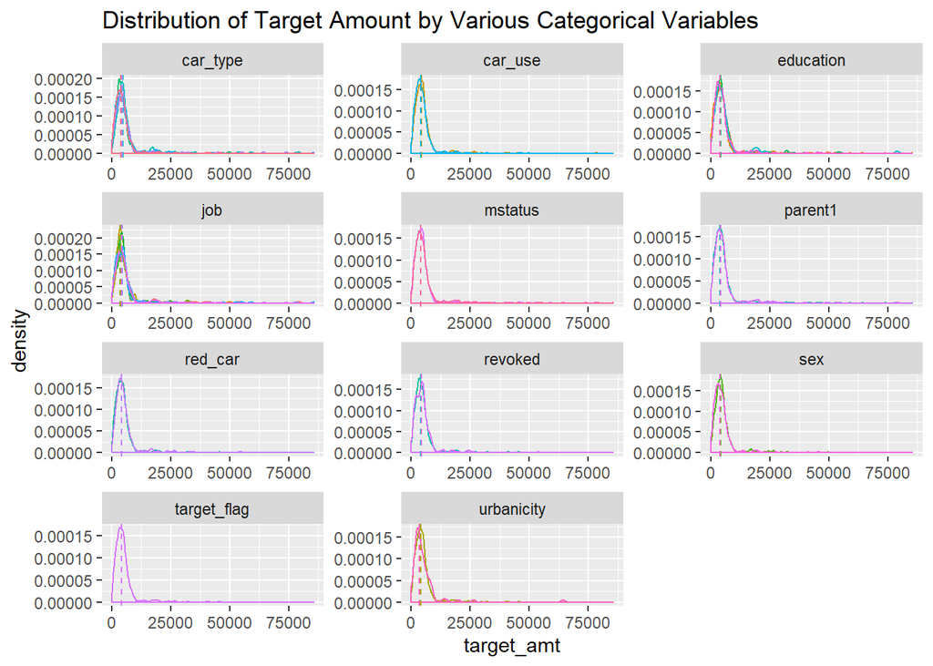

```r
# density - categorical variables
dfGather <- trainSet %>%
        dplyr::filter(target_flag == "Yes") %>%
        dplyr::select(fields %>% dplyr::filter(class == 'factor') %>% .$fields, target_amt) %>%
        tidyr::gather(key, value, -target_amt)

dfGather %>%
        ggplot(aes(target_amt, color = value)) +
        geom_density() +
        geom_vline(data = aggregate(target_amt ~ key + value, dfGather, median),
                   aes(xintercept = target_amt,
                       color = value),
                   linetype = "dashed") +
        facet_wrap(~ key, nrow = 5, scales = "free") +
        theme(legend.position = "none") +
        ggtitle("Distribution of Target Amount by Various Categorical Variables")
```

```r
# build full model
fullModel <- lm(target_amt ~., data = trainSet %>%
                        dplyr::filter(target_flag == "Yes") %>%
                        dplyr::select(variables, quant_var))
## Note: Using an external vector in selections is ambiguous.
## i Use `all_of(variables)` instead of `variables` to silence this message.
## i See <https://tidyselect.r-lib.org/reference/faq-external-vector.html>.
## This message is displayed once per session.
## Note: Using an external vector in selections is ambiguous.
## i Use `all_of(quant_var)` instead of `quant_var` to silence this message.
## i See <https://tidyselect.r-lib.org/reference/faq-external-vector.html>.
## This message is displayed once per session.
summary(fullModel)
```

```
##
## Call:
## lm(formula = target_amt ~ ., data = trainSet %>% dplyr::filter(target_flag ==
##     "Yes") %>% dplyr::select(variables, quant_var))
##
## Residuals:
##    Min     1Q Median     3Q    Max
##  -7646  -2980  -1428    479  78846
##
## Coefficients:
##                                 Estimate Std. Error t value Pr(>|t|)
## (Intercept)                      6420.76    1622.17   3.958 7.91e-05 ***
## kidsdriv                          -41.87     186.91  -0.224   0.8228
## age                                63.94     209.70   0.305   0.7605
## homekids                          241.18     275.06   0.877   0.3807
## yoj                                50.77     237.11   0.214   0.8305
## income                             26.37     243.05   0.109   0.9136
## parent1Yes                       -135.57     677.69  -0.200   0.8415
## home_val                          181.00     232.56   0.778   0.4365
## mstatusz_No                       855.11     534.28   1.600   0.1097
## sexz_F                          -1352.67     708.49  -1.909   0.0564 .
## educationBachelors               -176.93     740.56  -0.239   0.8112
## educationMasters                 1170.32    1245.90   0.939   0.3477
## educationPhD                     1820.80    1428.87   1.274   0.2028
## educationz_High School           -390.17     590.99  -0.660   0.5092
## jobClerical                      -465.61    1380.79  -0.337   0.7360
## jobDoctor                       -3129.01    2092.81  -1.495   0.1351
## jobHome Maker                    -851.86    1411.45  -0.604   0.5462
## jobLawyer                       -1153.76    1182.09  -0.976   0.3292
## jobManager                      -1606.24    1235.83  -1.300   0.1939
## jobProfessional                   286.88    1297.24   0.221   0.8250
## jobStudent                       -307.51    1454.56  -0.211   0.8326
## jobz_Blue Collar                   29.85    1320.61   0.023   0.9820
## travtime                           31.93     202.57   0.158   0.8748
## car_usePrivate                   -396.40     595.54  -0.666   0.5058
## bluebook                         -130.25     194.72  -0.669   0.5037
## tif                               -49.40     206.61  -0.239   0.8111
## car_typePanel Truck               806.16     962.96   0.837   0.4026
## car_typePickup                    -80.94     695.63  -0.116   0.9074
## car_typeSports Car                740.04     814.52   0.909   0.3637
## car_typeVan                       370.21     838.62   0.441   0.6589
## car_typez_SUV                     327.53     715.49   0.458   0.6472
## red_caryes                       -725.27     571.83  -1.268   0.2049
## oldclaim                          -56.25     220.52  -0.255   0.7987
## clm_freq                         -118.32     228.37  -0.518   0.6045
## revokedYes                       -756.60     485.77  -1.558   0.1196
## mvr_pts                           103.60     171.38   0.604   0.5456
## car_age                          -527.25     289.71  -1.820   0.0690 .
## urbanicityz_Highly Rural/ Rural   -52.34     877.12  -0.060   0.9524
## ---
## Signif. codes:  0 '***' 0.001 '**' 0.01 '*' 0.05 '.' 0.1 ' ' 1
##
## Residual standard error: 7391 on 1470 degrees of freedom
## Multiple R-squared:  0.02302,    Adjusted R-squared:  -0.001574
## F-statistic: 0.936 on 37 and 1470 DF,  p-value: 0.5804
```

```r
# stepwise regression - direction default to both
step <- MASS::stepAIC(fullModel, trace = FALSE)
step$anova
## Stepwise Model Path
## Analysis of Deviance Table
##
## Initial Model:
## target_amt ~ kidsdriv + age + homekids + yoj + income + parent1 +
##     home_val + mstatus + sex + education + job + travtime + car_use +
##     bluebook + tif + car_type + red_car + oldclaim + clm_freq +
##     revoked + mvr_pts + car_age + urbanicity
##
## Final Model:
## target_amt ~ mstatus + sex + car_use + revoked
##
##
##            Step Df  Deviance Resid. Df  Resid. Dev      AIC
## 1                                 1470 80306517739 26904.19
## 2         - job  8 350075913      1478 80656593652 26894.75
## 3    - car_type  5 156824305      1483 80813417957 26887.68
## 4   - education  4 209630349      1487 81023048307 26883.59
## 5    - kidsdriv  1    345385      1488 81023393692 26881.59
## 6     - parent1  1   1850124      1489 81025243816 26879.63
## 7  - urbanicity  1   2060081      1490 81027303897 26877.66
## 8    - travtime  1   2040288      1491 81029344185 26875.70
## 9         - tif  1   2786998      1492 81032131183 26873.75
## 10   - oldclaim  1   3433572      1493 81035564754 26871.82
## 11     - income  1   4926100      1494 81040490854 26869.91
## 12        - age  1  17593993      1495 81058084847 26868.24
## 13   - homekids  1  20065899      1496 81078150746 26866.61
## 14    - mvr_pts  1  24168604      1497 81102319350 26865.06
## 15   - clm_freq  1  17348896      1498 81119668246 26863.38
## 16   - bluebook  1  27790046      1499 81147458292 26861.90
## 17        - yoj  1  36399906      1500 81183858198 26860.58
## 18    - car_age  1  73266728      1501 81257124926 26859.94
## 19   - home_val  1  54967527      1502 81312092454 26858.96
## 20    - red_car  1  85939499      1503 81398031953 26858.55

# 2 degree of interactions - full model
step2 <- MASS::stepAIC(fullModel, ~ .^2, trace = FALSE)
step2$anova
## Stepwise Model Path
## Analysis of Deviance Table
##
## Initial Model:
## target_amt ~ kidsdriv + age + homekids + yoj + income + parent1 +
##     home_val + mstatus + sex + education + job + travtime + car_use +
##     bluebook + tif + car_type + red_car + oldclaim + clm_freq +
##     revoked + mvr_pts + car_age + urbanicity
##
## Final Model:
## target_amt ~ kidsdriv + age + homekids + yoj + income + home_val +
##     mstatus + sex + tif + car_type + red_car + oldclaim + clm_freq +
##     mvr_pts + car_age + urbanicity + homekids:clm_freq + homekids:car_type +
##     car_type:urbanicity + home_val:mstatus + age:car_type + kidsdriv:age +
##     income:mstatus + age:home_val + homekids:car_age + yoj:tif +
##     kidsdriv:oldclaim + income:car_type + homekids:red_car +
##     home_val:sex + homekids:home_val + kidsdriv:car_age + age:urbanicity +
##     home_val:oldclaim + age:red_car + age:clm_freq + kidsdriv:clm_freq
##
##
##                     Step Df     Deviance Resid. Df  Resid. Dev      AIC
## 1                                             1470 80306517739 26904.19
## 2    + homekids:clm_freq  1 6.753112e+08      1469 79631206509 26893.46
## 3    + homekids:car_type  5 1.011300e+09      1464 78619906978 26884.18
## 4                  - job  8 3.895629e+08      1472 79009469844 26875.64
## 5  + car_type:urbanicity  4 7.850784e+08      1468 78224391452 26868.58
## 6     + home_val:mstatus  1 4.600644e+08      1467 77764327040 26861.68
## 7         + age:car_type  5 8.447631e+08      1462 76919563928 26855.21
## 8            - education  4 1.752619e+08      1466 77094825815 26850.64
## 9         + kidsdriv:age  1 2.948190e+08      1465 76800006825 26846.86
## 10      + income:mstatus  1 2.600865e+08      1464 76539920341 26843.75
## 11        + age:home_val  1 2.833268e+08      1463 76256593508 26840.16
## 12    + homekids:car_age  1 2.494893e+08      1462 76007104200 26837.21
## 13             + yoj:tif  1 2.338405e+08      1461 75773263655 26834.57
## 14   + kidsdriv:oldclaim  1 2.327973e+08      1460 75540466362 26831.93
## 15            - travtime  1 5.909411e+03      1461 75540472271 26829.93
## 16     + income:car_type  5 5.975858e+08      1456 74942886461 26827.95
## 17             - parent1  1 6.248921e+06      1457 74949135382 26826.08
## 18             - car_use  1 2.510220e+07      1458 74974237583 26824.58
## 19            - bluebook  1 2.596424e+07      1459 75000201824 26823.10
## 20             - revoked  1 3.376960e+07      1460 75033971420 26821.78
## 21    + homekids:red_car  1 1.592836e+08      1459 74874687832 26820.58
## 22        + home_val:sex  1 1.455318e+08      1458 74729155997 26819.64
## 23   + homekids:home_val  1 1.492159e+08      1457 74579940090 26818.63
## 24    + kidsdriv:car_age  1 1.541971e+08      1456 74425743008 26817.51
## 25      + age:urbanicity  1 1.541162e+08      1455 74271626808 26816.38
## 26   + home_val:oldclaim  1 1.458966e+08      1454 74125730252 26815.42
## 27         + age:red_car  1 9.948659e+07      1453 74026243664 26815.39
## 28        + age:clm_freq  1 1.051529e+08      1452 73921090735 26815.25
## 29   + kidsdriv:clm_freq  1 1.467009e+08      1451 73774389817 26814.25

# 3 degree of interactions - full model
step3 <- MASS::stepAIC(fullModel, ~ .^3, trace = FALSE)
step3$anova
## Stepwise Model Path
## Analysis of Deviance Table
##
## Initial Model:
## target_amt ~ kidsdriv + age + homekids + yoj + income + parent1 +
##     home_val + mstatus + sex + education + job + travtime + car_use +
##     bluebook + tif + car_type + red_car + oldclaim + clm_freq +
##     revoked + mvr_pts + car_age + urbanicity
##
## Final Model:
## target_amt ~ kidsdriv + age + homekids + yoj + income + home_val +
##     mstatus + sex + tif + car_type + red_car + oldclaim + clm_freq +
##     mvr_pts + car_age + urbanicity + homekids:clm_freq + homekids:car_type +
##     car_type:urbanicity + home_val:mstatus + age:car_type + kidsdriv:age +
##     income:mstatus + age:home_val + homekids:car_age + yoj:tif +
##     kidsdriv:oldclaim + income:car_type + homekids:red_car +
##     home_val:sex + homekids:home_val + kidsdriv:car_age + age:urbanicity +
##     home_val:oldclaim + kidsdriv:clm_freq + age:clm_freq + age:car_type:urbanicity +
##     kidsdriv:age:clm_freq
##
##
##                         Step Df     Deviance Resid. Df  Resid. Dev      AIC
## 1                                                 1470 80306517739 26904.19
## 2        + homekids:clm_freq  1 6.753112e+08      1469 79631206509 26893.46
## 3        + homekids:car_type  5 1.011300e+09      1464 78619906978 26884.18
## 4                      - job  8 3.895629e+08      1472 79009469844 26875.64
## 5      + car_type:urbanicity  4 7.850784e+08      1468 78224391452 26868.58
## 6         + home_val:mstatus  1 4.600644e+08      1467 77764327040 26861.68
## 7             + age:car_type  5 8.447631e+08      1462 76919563928 26855.21
## 8                - education  4 1.752619e+08      1466 77094825815 26850.64
## 9             + kidsdriv:age  1 2.948190e+08      1465 76800006825 26846.86
## 10          + income:mstatus  1 2.600865e+08      1464 76539920341 26843.75
## 11            + age:home_val  1 2.833268e+08      1463 76256593508 26840.16
## 12        + homekids:car_age  1 2.494893e+08      1462 76007104200 26837.21
## 13                 + yoj:tif  1 2.338405e+08      1461 75773263655 26834.57
## 14       + kidsdriv:oldclaim  1 2.327973e+08      1460 75540466362 26831.93
## 15                - travtime  1 5.909411e+03      1461 75540472271 26829.93
## 16         + income:car_type  5 5.975858e+08      1456 74942886461 26827.95
## 17                 - parent1  1 6.248921e+06      1457 74949135382 26826.08
## 18                 - car_use  1 2.510220e+07      1458 74974237583 26824.58
## 19                - bluebook  1 2.596424e+07      1459 75000201824 26823.10
## 20                 - revoked  1 3.376960e+07      1460 75033971420 26821.78
## 21        + homekids:red_car  1 1.592836e+08      1459 74874687832 26820.58
## 22            + home_val:sex  1 1.455318e+08      1458 74729155997 26819.64
## 23       + homekids:home_val  1 1.492159e+08      1457 74579940090 26818.63
## 24        + kidsdriv:car_age  1 1.541971e+08      1456 74425743008 26817.51
## 25          + age:urbanicity  1 1.541162e+08      1455 74271626808 26816.38
## 26 + age:car_type:urbanicity  4 1.848856e+09      1451 72422770876 26786.37
## 27       + home_val:oldclaim  1 1.482064e+08      1450 72274564496 26785.28
## 28       + kidsdriv:clm_freq  1 1.109008e+08      1449 72163663686 26784.96
## 29            + age:clm_freq  1 1.759370e+08      1448 71987726674 26783.28
## 30   + kidsdriv:age:clm_freq  1 2.379337e+08      1447 71749793011 26780.29

# final model (based on the 3-degree of interactions)
finalModel <- lm(
        target_amt ~ kidsdriv + age + homekids + yoj + income + home_val +
            mstatus + sex + tif + car_type + red_car + oldclaim + clm_freq +
            mvr_pts + car_age + urbanicity + homekids:clm_freq + homekids:car_type +
            car_type:urbanicity + home_val:mstatus + age:car_type + kidsdriv:age +
            income:mstatus + age:home_val + homekids:car_age + yoj:tif +
            kidsdriv:oldclaim + income:car_type + homekids:red_car +
            home_val:sex + homekids:home_val + kidsdriv:car_age + age:urbanicity +
            home_val:oldclaim + kidsdriv:clm_freq + age:clm_freq + age:car_type:urbanicity +
            kidsdriv:age:clm_freq,
        data = trainSet %>%
                        dplyr::filter(target_flag == "Yes") %>%
                        dplyr::select(variables, quant_var)
)

summary(finalModel)
```

```
##
## Call:
## lm(formula = target_amt ~ kidsdriv + age + homekids + yoj + income +
##     home_val + mstatus + sex + tif + car_type + red_car + oldclaim +
##     clm_freq + mvr_pts + car_age + urbanicity + homekids:clm_freq +
##     homekids:car_type + car_type:urbanicity + home_val:mstatus +
##     age:car_type + kidsdriv:age + income:mstatus + age:home_val +
##     homekids:car_age + yoj:tif + kidsdriv:oldclaim + income:car_type +
##     homekids:red_car + home_val:sex + homekids:home_val + kidsdriv:car_age +
##     age:urbanicity + home_val:oldclaim + kidsdriv:clm_freq +
##     age:clm_freq + age:car_type:urbanicity + kidsdriv:age:clm_freq,
##     data = trainSet %>% dplyr::filter(target_flag == "Yes") %>%
##         dplyr::select(variables, quant_var))
##
## Residuals:
##    Min     1Q Median     3Q    Max
## -18504  -3101  -1091    912  75691
##
## Coefficients: (2 not defined because of singularities)
##                                                         Estimate Std. Error
## (Intercept)                                              6157.26     664.87
## kidsdriv                                                 -220.46     203.47
## age                                                       421.19     480.96
## homekids                                                  442.93     541.58
## yoj                                                      -104.28     201.34
## income                                                  -1780.86     525.57
## home_val                                                  -77.16     385.25
## mstatusz_No                                              1194.44     432.93
## sexz_F                                                  -1264.66     689.06
## tif                                                       -47.34     199.78
## car_typePanel Truck                                      1227.58     825.18
## car_typePickup                                           -371.90     661.09
## car_typeSports Car                                        431.36     813.56
## car_typeVan                                              -176.79     798.68
## car_typez_SUV                                            -285.40     710.90
## red_caryes                                               -368.62     548.91
## oldclaim                                                   21.94     214.98
## clm_freq                                                 -166.52     219.32
## mvr_pts                                                   259.13     166.20
## car_age                                                  -287.20     208.52
```

[output cut: 98 more lines]

```
## home_val:oldclaim                                         1.535 0.125010
## kidsdriv:clm_freq                                        -1.702 0.088983 .
## age:clm_freq                                              1.873 0.061221 .
## age:car_typePanel Truck:urbanicityz_Highly Rural/ Rural      NA       NA
## age:car_typePickup:urbanicityz_Highly Rural/ Rural        1.708 0.087891 .
## age:car_typeSports Car:urbanicityz_Highly Rural/ Rural    0.393 0.694368
## age:car_typeVan:urbanicityz_Highly Rural/ Rural           5.795 8.38e-09 ***
## age:car_typez_SUV:urbanicityz_Highly Rural/ Rural         0.236 0.813289
## kidsdriv:age:clm_freq                                     2.191 0.028644 *
## ---
## Signif. codes:  0 '***' 0.001 '**' 0.01 '*' 0.05 '.' 0.1 ' ' 1
##
## Residual standard error: 7042 on 1447 degrees of freedom
## Multiple R-squared:  0.1271, Adjusted R-squared:  0.09092
## F-statistic: 3.512 on 60 and 1447 DF,  p-value: < 2.2e-16
```

```r
broom::tidy(finalModel) %>% arrange(p.value) %>% kable()
```

| term | estimate | std.error | statistic | p.value |
| --- | --- | --- | --- | --- |
| (Intercept) | 6157.26102 | 664.8728 | 9.2608107 | 0.0000000 |
| age:car_typeVan:urbanicityz_Highly Rural/ Rural | 17335.74875 | 2991.6108 | 5.7947874 | 0.0000000 |
| car_typeVan:urbanicityz_Highly Rural/ Rural | 20566.08610 | 3644.5828 | 5.6429191 | 0.0000000 |
| homekids:car_typePanel Truck | 3451.01882 | 835.1349 | 4.1322889 | 0.0000380 |
| home_val:mstatusz_No | 1567.46217 | 438.0585 | 3.5782032 | 0.0003574 |
| age:home_val | 677.15735 | 192.6520 | 3.5149249 | 0.0004534 |
| income | -1780.85560 | 525.5706 | -3.3884234 | 0.0007218 |
| homekids:clm_freq | 735.40808 | 228.3909 | 3.2199540 | 0.0013106 |
| income:car_typeSports Car | 2065.99967 | 689.2879 | 2.9972959 | 0.0027703 |
| homekids:car_age | 695.12298 | 234.3885 | 2.9656877 | 0.0030696 |
| income:car_typePickup | 1929.04279 | 673.5836 | 2.8638507 | 0.0042456 |
| kidsdriv:oldclaim | 476.49886 | 172.2145 | 2.7668918 | 0.0057314 |
| mstatusz_No | 1194.43930 | 432.9270 | 2.7589854 | 0.0058712 |
| income:mstatusz_No | 1066.00114 | 388.4118 | 2.7445130 | 0.0061350 |
| age:car_typeVan | -2235.39108 | 824.4937 | -2.7112287 | 0.0067827 |
| income:car_typez_SUV | 1564.40159 | 584.4488 | 2.6767129 | 0.0075188 |
| age:car_typePanel Truck | 1924.33174 | 824.4782 | 2.3339996 | 0.0197320 |
| yoj:tif | -418.87507 | 180.0818 | -2.3260261 | 0.0201547 |
| income:car_typeVan | 1701.51669 | 737.9440 | 2.3057532 | 0.0212653 |
| homekids:home_val | 468.86746 | 210.2472 | 2.2300770 | 0.0258952 |
| kidsdriv:age:clm_freq | 354.29002 | 161.7361 | 2.1905435 | 0.0286439 |
| homekids:red_caryes | -1015.10786 | 470.4060 | -2.1579398 | 0.0310966 |
| kidsdriv:car_age | -369.24951 | 180.4533 | -2.0462326 | 0.0409139 |
| car_typePickup:urbanicityz_Highly Rural/ Rural | 5557.24992 | 2881.3229 | 1.9287147 | 0.0539617 |
| age:clm_freq | 328.15357 | 175.1687 | 1.8733572 | 0.0612205 |
| sexz_F | -1264.65757 | 689.0559 | -1.8353484 | 0.0666592 |
| urbanicityz_Highly Rural/ Rural | -3096.97458 | 1774.2871 | -1.7454755 | 0.0811144 |
| age:car_typePickup:urbanicityz_Highly Rural/ Rural | 5226.65734 | 3060.4936 | 1.7077825 | 0.0878912 |
| kidsdriv:clm_freq | -336.48308 | 197.7066 | -1.7019313 | 0.0889831 |
| home_val:sexz_F | -682.46038 | 401.2797 | -1.7007098 | 0.0892124 |
| mvr_pts | 259.13257 | 166.2033 | 1.5591304 | 0.1191842 |
| home_val:oldclaim | 272.92888 | 177.8076 | 1.5349677 | 0.1250104 |
| income:car_typePanel Truck | 1169.47047 | 775.8212 | 1.5073968 | 0.1319273 |
| car_typePanel Truck | 1227.58097 | 825.1824 | 1.4876480 | 0.1370616 |
| car_age | -287.20185 | 208.5190 | -1.3773414 | 0.1686197 |
| kidsdriv:age | 266.51728 | 216.7747 | 1.2294669 | 0.2190967 |
| homekids:car_typeSports Car | -842.79430 | 724.1426 | -1.1638513 | 0.2446761 |
| car_typez_SUV:urbanicityz_Highly Rural/ Rural | 2609.11289 | 2294.8677 | 1.1369339 | 0.2557542 |
| kidsdriv | -220.46485 | 203.4723 | -1.0835129 | 0.2787613 |
| homekids:car_typePickup | 657.80690 | 640.9177 | 1.0263516 | 0.3048974 |
| age | 421.19239 | 480.9643 | 0.8757249 | 0.3813249 |
| homekids:car_typeVan | -678.25917 | 816.9334 | -0.8302502 | 0.4065343 |
| homekids | 442.92558 | 541.5782 | 0.8178423 | 0.4135819 |
| clm_freq | -166.51752 | 219.3169 | -0.7592554 | 0.4478235 |
| car_typeSports Car:urbanicityz_Highly Rural/ Rural | 2089.92132 | 2894.1821 | 0.7221112 | 0.4703428 |
| red_caryes | -368.62000 | 548.9139 | -0.6715443 | 0.5019810 |
| age:car_typez_SUV | -375.29216 | 575.1881 | -0.6524686 | 0.5142026 |
| age:car_typeSports Car | -391.09925 | 638.7256 | -0.6123118 | 0.5404277 |
| car_typePickup | -371.90288 | 661.0853 | -0.5625641 | 0.5738189 |
| age:urbanicityz_Highly Rural/ Rural | -702.84499 | 1300.1613 | -0.5405829 | 0.5888783 |
| car_typeSports Car | 431.35601 | 813.5639 | 0.5302055 | 0.5960508 |
| yoj | -104.27931 | 201.3376 | -0.5179326 | 0.6045845 |
| car_typez_SUV | -285.39708 | 710.9025 | -0.4014574 | 0.6881427 |
| age:car_typeSports Car:urbanicityz_Highly Rural/ Rural | 882.65837 | 2245.8772 | 0.3930128 | 0.6943680 |
| tif | -47.34196 | 199.7847 | -0.2369649 | 0.8127176 |
| age:car_typez_SUV:urbanicityz_Highly Rural/ Rural | 428.85546 | 1815.4302 | 0.2362280 | 0.8132892 |
| car_typeVan | -176.79136 | 798.6800 | -0.2213544 | 0.8248477 |
| homekids:car_typez_SUV | -128.95172 | 611.7876 | -0.2107786 | 0.8330897 |
| home_val | -77.16001 | 385.2538 | -0.2002836 | 0.8412869 |
| oldclaim | 21.94131 | 214.9811 | 0.1020616 | 0.9187219 |
| age:car_typePickup | -38.01724 | 680.7042 | -0.0558499 | 0.9554691 |

```r
# comparison
testSet$target_amt_predicted <- predict(finalModel, testSet[, variables])

# root mean squared error (rmse)
Metrics::rmse(testSet$target_amt, testSet$target_amt_predicted)
```

```
## [1] 7343.597
```

## MODEL APPLIED - MULTILINEAR REGRESSION (TARGET_AMT)

From above corrplot and density curve, we see that there’s actually nothing strongly associated with the target variable. We used stepwise regression and used up to three degree of interaction to come up with the best model possible (which will cause overfitting and make this model useless in the future), but still that only gave us 9% of adjusted R-squared. That means, over 90% of the variance in the actual amount cannot be predicted from this model. The regression model is less encouraging than the classification model.

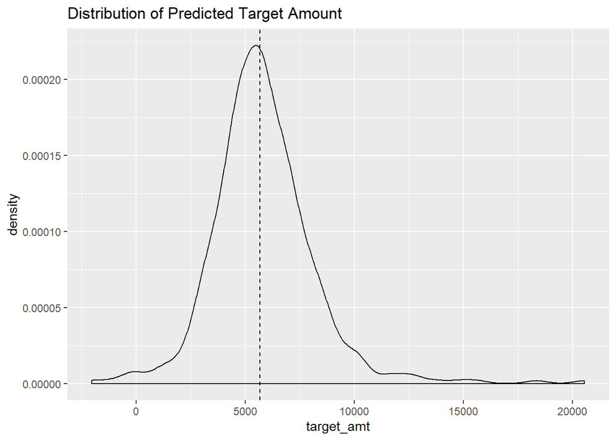

```r
dfEval$target_amt <- predict(finalModel, dfEval[, variables])

dfEval %>%
        dplyr::filter(target_flag == "Yes") %>%
        ggplot(aes(target_amt)) +
        geom_density() +
        geom_vline(xintercept = median(dfEval$target_amt[dfEval$target_flag == "Yes"]),
                   linetype = "dashed") +
        ggtitle("Distribution of Predicted Target Amount")
```

```r
dfEval %>% head() %>% kable()
```

| index | target_flag | target_amt | kidsdriv | age | homekids | yoj | income | parent1 | home_val | mstatus | sex | education | job | travtime | car_use | bluebook | tif | car_type | red_car | oldclaim | clm_freq | revoked | mvr_pts | car_age | urbanicity | OOF_pred_glm | OOF_pred_nb | OOF_pred_rf | OOF_pred_top_glm | … |
| --- | --- | --- | --- | --- | --- | --- | --- | --- | --- | --- | --- | --- | --- | --- | --- | --- | --- | --- | --- | --- | --- | --- | --- | --- | --- | --- | --- | --- | --- | --- |
| 3 | No | 6783.665 | -0.3337943 | 0.3499326 | -0.6425179 | 0.1488987 | 0.6619537 | No | -0.9915932 | z_No | M | Bachelors | Manager | -0.4549095 | Private | 0.0016269 | -1.0689293 | Van | yes | -0.6571645 | -0.7111922 | No | 0.1062001 | 0.3150395 | Highly Urban/ Urban | 0.1220784 | 0.0013785 | 0.092 | 0.0915576 | … |
| 9 | No | 5900.963 | 1.7198080 | -0.5884831 | 0.2530751 | 0.1488987 | 0.6011222 | Yes | -0.9915932 | z_No | M | z_High School | Manager | -0.7729272 | Private | -0.3709252 | 0.1901913 | Minivan | no | 0.4022653 | 0.1679432 | No | 0.1062001 | -1.2457634 | Highly Urban/ Urban | 0.2336235 | 0.2439135 | 0.328 | 0.2164859 | … |
| 10 | No | 4250.961 | -0.3337943 | -0.1192753 | 1.1486681 | 0.3887064 | 0.3491062 | Yes | -0.9915932 | z_No | z_F | z_High School | z_Blue Collar | -0.2004953 | Commercial | 1.1124265 | 1.1974878 | z_SUV | no | -0.6571645 | -0.7111922 | No | -0.8014825 | 0.3150395 | z_Highly Rural/ Rural | 0.0908932 | 0.0091209 | 0.012 | 0.0667108 | … |
| 18 | No | 2521.773 | -0.3337943 | -1.1749930 | 1.1486681 | 0.1488987 | -0.4521312 | Yes | -0.9915932 | z_No | M | z_High School | Clerical | 2.5980610 | Private | 1.5329762 | 0.1901913 | Pickup | no | -0.6571645 | -0.7111922 | Yes | -0.8014825 | -0.7254958 | z_Highly Rural/ Rural | 0.2403932 | 0.0106405 | 0.112 | 0.1351010 | … |
| 21 | No | 5053.206 | -0.3337943 | 1.6402542 | -0.6425179 | 0.3887064 | 1.5865921 | No | -0.9915932 | z_No | M | z_High School | Manager | 0.7535580 | Private | -0.8166164 | -1.0689293 | Minivan | yes | 1.2701376 | 1.0470786 | No | 1.0138828 | -1.2457634 | Highly Urban/ Urban | 0.2392829 | 0.0536335 | 0.256 | 0.1920650 | … |
| 30 | No | 5818.214 | -0.3337943 | 0.1153287 | -0.6425179 | 0.8683218 | -1.3420087 | No | 0.3708270 | Yes | M | Bachelors | Professional | -1.6633769 | Commercial | 0.3696079 | -1.0689293 | Panel Truck | no | -0.1254949 | 0.1679432 | No | 0.1062001 | 0.6618846 | Highly Urban/ Urban | 0.1864743 | 0.0259940 | 0.226 | 0.1558029 | … |